# Data Translation Challenge

Reyn Okinaga

2024-05-08

```r
#import libraries
library(rio)
library(tidyverse)
library(vtable)
```

```r
library(ggplot2)
library(lubridate)
library(forcats)
library(scales)
sales <- import('sales_data.Rdata')
zip_info <- import('zip_info.csv')
```

```r
vtable(sales, lush = TRUE)
```

sales

| Name | Class | Values | Missing | Summary |
| --- | --- | --- | --- | --- |
| Product | character | ‘20in Monitor’ ‘27in 4K Gaming Monitor’ ‘27in FHD Monitor’ ‘34in Ultrawide Monitor’ ‘AA Batteries (4-pack)’ and 14 more | 0 | nuniq: 19 |
| Quantity | character | ‘1’ ‘2’ ‘3’ ‘4’ ‘5’ and 4 more | 0 | nuniq: 9 |
| PriceEach | character | ‘109.99’ ‘11.95’ ‘11.99’ ‘14.95’ ‘149.99’ and 18 more | 0 | nuniq: 23 |
| DateTime | POSIXct | Time: 2019-01-01 03:07:00 to 2020-01-01 05:13:00 | 0 | median: 2019-07-17 20:40:30, nuniq: 142395 |
| Date | Date | Time: 2019-01-01 to 2020-01-01 | 0 | median: 2019-07-17, nuniq: 366 |
| ZIP | character | ‘02215’ ‘04101’ ‘10001’ ‘30301’ ‘73301’ and 5 more | 0 | nuniq: 10 |
| State | character | ‘CA’ ‘GA’ ‘MA’ ‘ME’ ‘NY’ and 3 more | 0 | nuniq: 8 |
| City | character | ‘Atlanta’ ‘Austin’ ‘Boston’ ‘Dallas’ ‘Los Angeles’ and 4 more | 0 | nuniq: 9 |

```r
sales <- sales %>%
  mutate(Quantity = as.numeric(Quantity)) %>%
  mutate(PriceEach = as.numeric(PriceEach)) %>%
  mutate(ZIP = as.numeric(ZIP))
```

Dear Managers of Amazon’s Technology Product Division,

I wanted to first highlight that the top products we are selling by number of units are batteries, followed by charging cables and headphones (see data visual 1). This is important to know because it is vital to keep these items in consistent stock, as they tend to sell often compared to other technology products and customers will always be looking to buy these products.

Apart from knowing which products sell the most, it might be useful to know you might want to know which products produces the highest revenue. By multiplying the average price by the sales for the year, I found the highest revenue is brought in from MacBook Pro Laptop 1, followed by iPhone and ThinkPad Laptops (see data visual 2).

Although these products bring in the highest revenue, we may also want to see which products are bringing in the highest average revenue because it will show which products will have the highest revenue per unit of output sold, and therefore making it more profitable to sell. The technology products selling for the highest revenue on average are MacBook Pro Laptop 1, followed by ThinkPad Laptop and iPhone (see data visual 3). The MacBook Pro Laptops, by far, create the most revenue for selling a singular unit. Possibly, this can be because of there may be a small amount of laptops sold, due to high prices of average or maybe this simply means less customers want laptops over other technology product? Anyways, this leads us to questions and we should investigate more into this. Let’s look at whether or not sales of these laptops are declining or increasing.

Diving in further into the information, let’s look into the sales trends of the MacBook Pro Laptops. We can see that there was a slight sales peak around mid-year, followed by a dip towards the third quarter, but an overall increase at the end of the year (see data visual 4). This graph helps us better understand the overall sales patterns of the laptop and provides a more complete picture of our sales story. Now that we know that sales are still increasing for these laptops, let’s see which cities should increase their inventory stock as well as suggestions on where to keep marketing the MacBook Pro Laptops.

To see which cities to target, I graphed the number of MacBook Pro Laptops sold in each Urban City (see data visual 5). Of the nine cities, the most MacBook Pro Laptops were sold in San Fransicso, followed by Los Angeles and New York City. With this data, it will be useful to know that targeting residents from these cities will allow us to maximize one of our main sources of revenue through the selling of MacBook Pro Laptops.

**Data** **Visualization 1:**

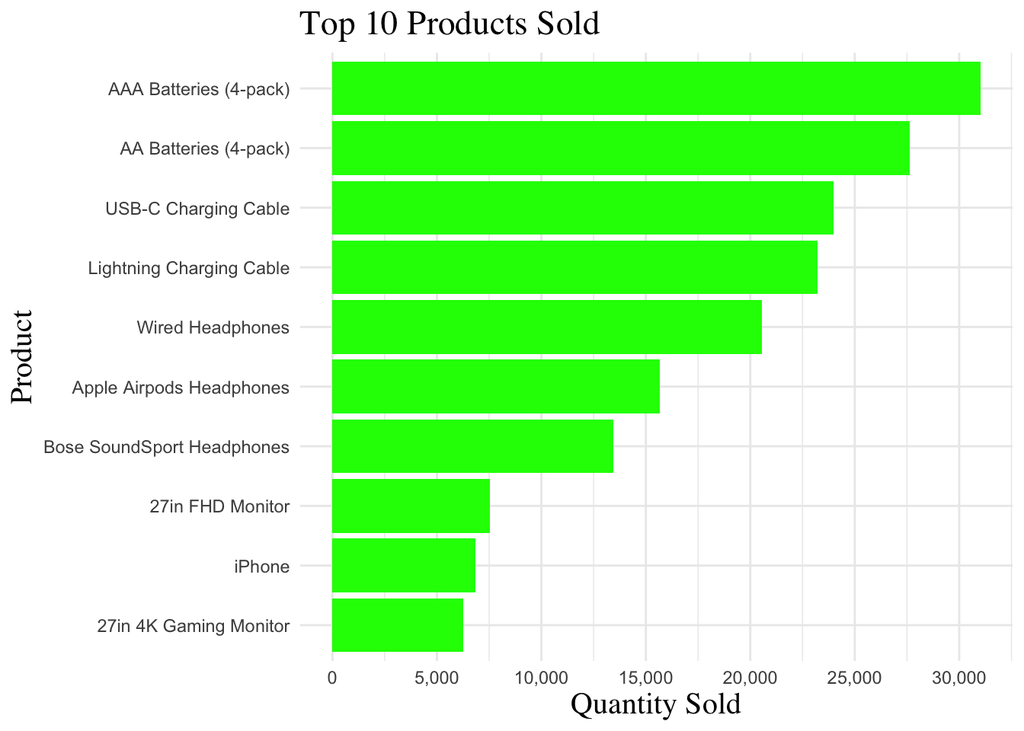

```r
top10Products <- sales %>%
  group_by(Product) %>%
  summarize(totalQuantity = sum(Quantity)) %>%
  arrange(desc(totalQuantity)) %>%
  head(10)

ggplot(top10Products, aes(x = reorder(Product, totalQuantity), y = totalQuantity)) + geom_bar(stat = "identity", fill = "green") +
coord_flip() + scale_y_continuous(labels = comma_format(big.mark = ","), breaks = seq(0, 30000, by = 5000)) + labs(x = "Product", y = "Quantity Sold", title = "Top 10 Products Sold") + theme_minimal() +
theme(axis.title.x = element_text(size = 15, family = "serif"), axis.title.y = element_text(size = 15, family = "serif"), plot.title = element_text(size = 17, family = "serif"))
```

**Data Visualization 2:**

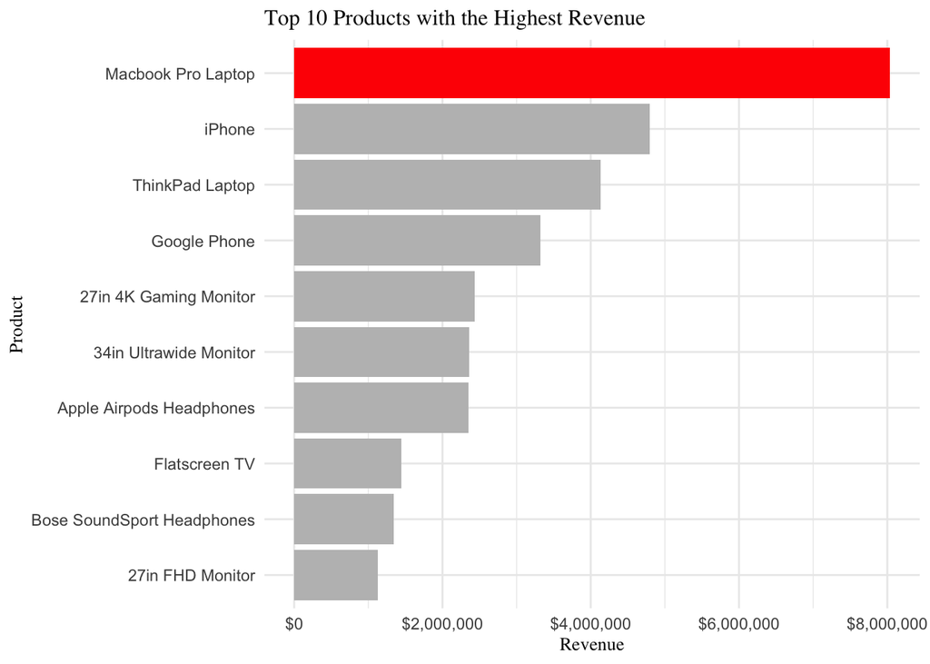

```r
totalrevenue <- sales %>%
  group_by(Product) %>%
  summarize(TRproduct = sum(Quantity * PriceEach)) %>%
  arrange(desc(TRproduct)) %>%
  head(10)

ggplot(totalrevenue, aes(x = reorder(Product, TRproduct), y = TRproduct)) + geom_bar(stat = "identity", fill = c('red', 'grey','grey', 'grey','grey', 'grey','grey', 'grey','grey', 'grey')) + coord_flip() + scale_y_continuous(labels = dollar_format(prefix = "$")) + labs(x = "Product", y = "Revenue", title = "Top 10 Products with the Highest Revenue") + theme_minimal() + theme(axis.title.x = element_text(size = 10, family = "serif"), axis.title.y = element_text(size = 10, family = "serif"), plot.title = element_text(size = 12, family = "serif"))
```

**Data Visualization 3:**

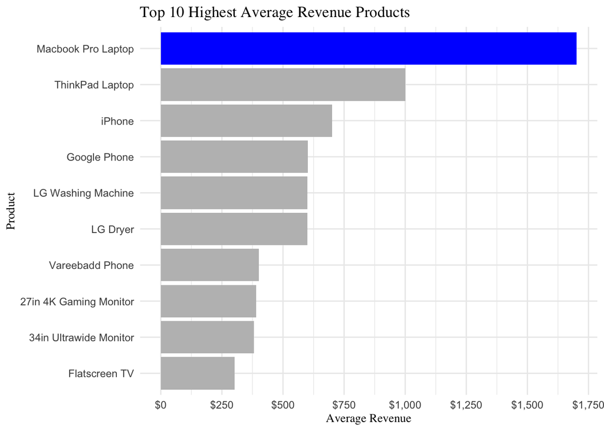

```r
ARperSale <- sales %>%
  group_by(Product) %>%
  summarize(avgRev = mean(Quantity * PriceEach)) %>%
  arrange(desc(avgRev)) %>%
  head(10)

ggplot(ARperSale, aes(x = reorder(Product, avgRev), y = avgRev)) +
geom_col(fill = c('blue', 'grey','grey', 'grey','grey', 'grey','grey', 'grey','grey', 'grey')) + coord_flip() + labs(x = "Product", y = "Average Revenue", title = "Top 10 Highest Average Revenue Products") + scale_y_continuous(labels = dollar_format(prefix = "$"), breaks = seq(0, 1750, by = 250)) + theme_minimal() + theme(axis.title.x = element_text(size = 10, family = "serif"), axis.title.y = element_text(size = 10, family = "serif"), plot.title = element_text(size = 13, family = "serif"))
```

**Data Visualization 4:**

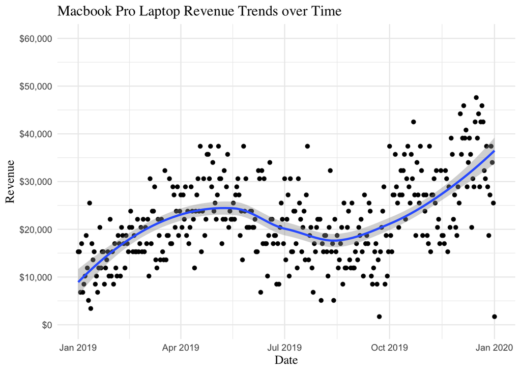

```r
LaptopSales <- sales %>%
  group_by(Date) %>%
  filter(Product == 'Macbook Pro Laptop') %>%
  summarise(LS = sum(Quantity * PriceEach))

ggplot(LaptopSales, aes(x= Date, y= LS)) +
geom_point() + geom_smooth() +
labs(title = "Macbook Pro Laptop Revenue Trends over Time", x = "Date", y = "Revenue") +
scale_y_continuous(labels = dollar_format(prefix = "$"), limits = c(0, 60000), breaks = seq(0, 60000,
by = 10000)) +
theme_minimal() +
theme(axis.title.x = element_text(size = 12, family = "serif"),
axis.title.y = element_text(size = 12, family = "serif"), plot.title = element_text(size = 14, family = "serif"))
```

**Data Visualization 5:**

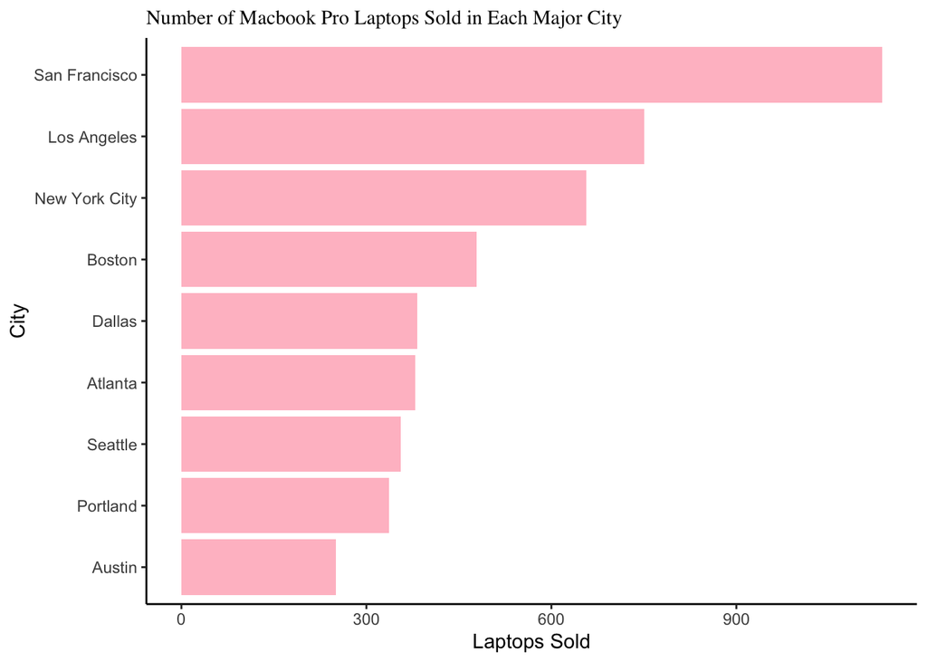

```r
Laptop <- sales %>%
  filter(Product == 'Macbook Pro Laptop') %>%
  group_by(City) %>%
  summarize(count = sum(Quantity)) %>%
  arrange(-count)

ggplot(Laptop, aes(x = count, y = reorder(City, count))) +
geom_col(fill = "pink") + theme_classic() +
xlab('Laptops Sold') +
ylab('City') +
labs(title = 'Number of Macbook Pro Laptops Sold in Each Major City', hujst = 0.5) + theme(plot.title = element_text(size = 11, family = "serif"))
```